# Project: Investigate a Dataset - NoShow Appointments

- 1. Introduction
  - 1.1. Dataset Description
  - 1.2. Question(s) for Analysis
  - 1.3. Import Packages
- 2. Data Wrangling
- 3. Data Cleaning
- 4. Feature Engineering
- 5. Exploratory Data Analysis
  - 5.1. Were there patients who missed appointments?
  - 5.3. What was the distribution like for appointment waiting times?
  - 5.4. What areas had the shortest and longest wait times?
  - 5.5. Which timeframes with the highest and lowest appointments?
  - 5.6. Is there a correlation between the waiting time and no-show ups?
  - 5.7. What gender was most likely to miss and of what age?
  - 5.8. Which area was hit headest by patients who didn't show up?
  - 5.9. Which areas had the most and least appointments?
  - 5.2. Did the patients who received an sms(es) more likely show up?
- 6. Conclusions
  - 6.1. Limitations
  - 6.2. References

## Introduction

### Dataset Description

> This dataset collects information from 100k medical appointments in Brazil and is focused on the question of whether or not patients show up for their appointment. A number of characteristics about the patient are included in each row.
1. PatientId: Uniqe identification of each patient
2. AppointmentID: Unique identification of each appointment
3. Gender: Male or Female
4. ScheduledDay: The day the patient set up their appointment.
5. Age: How old the patient is.
6. Neighborhood: The location of the hospital.
7. Scholarship: Indicates whether or not the patient is enrolled in Brasilian welfare program [Bolsa Família](https://en.wikipedia.org/wiki/Bolsa_Fam%C3%ADlia).
8. Hypertension: Whether a patient has it(True or False).
9. Diabetes: Whether a patient has it(True or False).
10. Alcoholism: Whether a patient has it(True or False).
11. Handicap; Whether a patient is(True or False).
12. SmsReceived: Messages sent to the patient.
13. NoShow: Shows whether a patient showed up or not. Says ‘No’ if the patient showed up to their appointment, and ‘Yes’ if they did not show up.

[Click here to view the dataset source](https://www.kaggle.com/datasets/joniarroba/noshowappointments).

### Questions for Analysis

My questions for this dataset are split into two main areas of concern. How **TIME** and **POPULATION** play in this dataset.

> **Demography**:
> 1. Were there patients who missed appointments?
> 2. What was the distribution like for appointment waiting times?
> 3. What areas had the shortest and longest wait times?
> 4. Timeframes with the highest and lowest appointments?
> 5. Is there a correlation between the waiting time and no-show ups?
> 6. What gender was most likely to miss and of what age?
> 7. Which area was hit headest by patients who didn't show up?
> 8. Which areas had the most and least appointments?
> 9. Did the patients who received an sms(es) more likely show up?
> 10. What factors correlate?

### Import the Necessary Modules

```python
# Importing necessary packages
import pandas as pd
import numpy as np

from datetime import datetime

import seaborn as sns
import matplotlib.pyplot as plt
from matplotlib.ticker import StrMethodFormatter
%matplotlib inline

sns.set_style('darkgrid')
```

```python
# Upgrade pandas to use dataframe.explode() function.
!pip install --upgrade pandas==0.25.0
```

[output not shown]

[output cut: 1853 more lines]

[output not shown]

## Data Wrangling

> In this section of the report, I am loading in the data, checking for cleanliness and a brief overview to get a look at what the data looks like.

```python
# Loading the raw dataset
df_raw = pd.read_csv('noshowappointments-kagglev2-may-2016.csv')

# Assign the raw dataset to another df ensuring I am not editing the raw dataset
df_noshow = df_raw

# Quick look into the first 5 rows of the df
df_noshow.head()
```

|  | PatientId | AppointmentID | Gender | ScheduledDay | AppointmentDay | Age | Neighbourhood | Scholarship | Hipertension | Diabetes | Alcoholism | Handcap | SMS_received | No-show |
| --- | --- | --- | --- | --- | --- | --- | --- | --- | --- | --- | --- | --- | --- | --- |
| 0 | 2.987250e+13 | 5642903 | F | 2016-04-29T18:38:08Z | 2016-04-29T00:00:00Z | 62 | JARDIM DA PENHA | 0 | 1 | 0 | 0 | 0 | 0 | No |
| 1 | 5.589978e+14 | 5642503 | M | 2016-04-29T16:08:27Z | 2016-04-29T00:00:00Z | 56 | JARDIM DA PENHA | 0 | 0 | 0 | 0 | 0 | 0 | No |
| 2 | 4.262962e+12 | 5642549 | F | 2016-04-29T16:19:04Z | 2016-04-29T00:00:00Z | 62 | MATA DA PRAIA | 0 | 0 | 0 | 0 | 0 | 0 | No |
| 3 | 8.679512e+11 | 5642828 | F | 2016-04-29T17:29:31Z | 2016-04-29T00:00:00Z | 8 | PONTAL DE CAMBURI | 0 | 0 | 0 | 0 | 0 | 0 | No |
| 4 | 8.841186e+12 | 5642494 | F | 2016-04-29T16:07:23Z | 2016-04-29T00:00:00Z | 56 | JARDIM DA PENHA | 0 | 1 | 1 | 0 | 0 | 0 | No |

```python
# Checking the shape of the dataset: No of Columns and Rows
df_noshow.shape
```

```
(110527, 14)
```

```python
# Checking the df data-types
df_noshow.dtypes
```

```
PatientId         float64
AppointmentID       int64
Gender             object
ScheduledDay       object
AppointmentDay     object
Age                 int64
Neighbourhood      object
Scholarship         int64
Hipertension        int64
Diabetes            int64
Alcoholism          int64
Handcap             int64
SMS_received        int64
No-show            object
dtype: object
```

```python
# More detailed view of the shape of the dataset: size of columns, NaN values and datatypes
df_noshow.info()
```

```
<class 'pandas.core.frame.DataFrame'>
RangeIndex: 110527 entries, 0 to 110526
Data columns (total 14 columns):
 #   Column          Non-Null Count   Dtype
---  ------          --------------   -----
 0   PatientId       110527 non-null  float64
 1   AppointmentID   110527 non-null  int64
 2   Gender          110527 non-null  object
 3   ScheduledDay    110527 non-null  object
 4   AppointmentDay  110527 non-null  object
 5   Age             110527 non-null  int64
 6   Neighbourhood   110527 non-null  object
 7   Scholarship     110527 non-null  int64
 8   Hipertension    110527 non-null  int64
 9   Diabetes        110527 non-null  int64
 10  Alcoholism      110527 non-null  int64
 11  Handcap         110527 non-null  int64
 12  SMS_received    110527 non-null  int64
 13  No-show         110527 non-null  object
dtypes: float64(1), int64(8), object(5)
memory usage: 11.8+ MB
```

```python
# Statistical summary of the dataset
df_noshow.describe()
```

|  | PatientId | AppointmentID | Age | Scholarship | Hipertension | Diabetes | Alcoholism | Handcap | SMS_received |
| --- | --- | --- | --- | --- | --- | --- | --- | --- | --- |
| count | 1.105270e+05 | 1.105270e+05 | 110527.000000 | 110527.000000 | 110527.000000 | 110527.000000 | 110527.000000 | 110527.000000 | 110527.000000 |
| mean | 1.474963e+14 | 5.675305e+06 | 37.088874 | 0.098266 | 0.197246 | 0.071865 | 0.030400 | 0.022248 | 0.321026 |
| std | 2.560949e+14 | 7.129575e+04 | 23.110205 | 0.297675 | 0.397921 | 0.258265 | 0.171686 | 0.161543 | 0.466873 |
| min | 3.921784e+04 | 5.030230e+06 | -1.000000 | 0.000000 | 0.000000 | 0.000000 | 0.000000 | 0.000000 | 0.000000 |
| 25% | 4.172614e+12 | 5.640286e+06 | 18.000000 | 0.000000 | 0.000000 | 0.000000 | 0.000000 | 0.000000 | 0.000000 |
| 50% | 3.173184e+13 | 5.680573e+06 | 37.000000 | 0.000000 | 0.000000 | 0.000000 | 0.000000 | 0.000000 | 0.000000 |
| 75% | 9.439172e+13 | 5.725524e+06 | 55.000000 | 0.000000 | 0.000000 | 0.000000 | 0.000000 | 0.000000 | 1.000000 |
| max | 9.999816e+14 | 5.790484e+06 | 115.000000 | 1.000000 | 1.000000 | 1.000000 | 1.000000 | 4.000000 | 1.000000 |

```python
# Show count of Patients before data editing
Before_edit = df_noshow.groupby(['No-show']).size()
Before_edit
```

```
No-show
No     88208
Yes    22319
dtype: int64
```

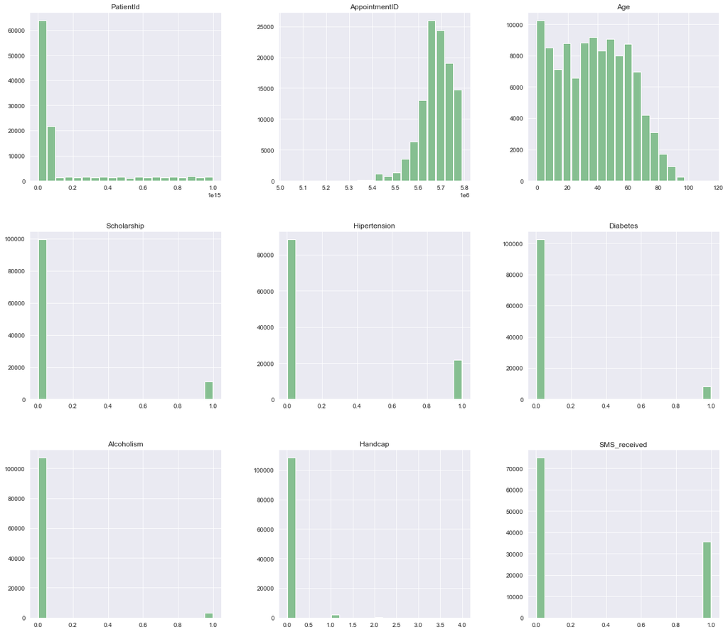

```python
# Explore the data before cleaning

ax = df_noshow.hist(figsize=(20,18),bins=20, grid=True, color='#86bf91', zorder=2, rwidth=0.9)
ax = ax[0]

def hist_plot():
    for x in ax:
        x.spines['right'].set_visible(False)
        x.spines['top'].set_visible(False)
        x.spines['left'].set_visible(False)

    # Switch off ticks
        x.tick_params(axis="both", which="both", bottom="off", top="off", labelbottom="on", left="off", right="off", labelleft="on")

    # Draw horizontal axis lines
        vals = x.get_yticks()
        for tick in vals:
            x.axhline(y=tick, linestyle='dashed', alpha=0.4, color='#eeeeee', zorder=1)

    # Format y-axis label
        x.yaxis.set_major_formatter(StrMethodFormatter('{x:,g}'))
        ax = plt.subplot(1,1,1)
        ax.hist(x)
        ax.set_xlabel(xlabel)
        ax.set_ylabel(ylabel)
        plt.show()
```

## Data Cleaning

> The Goal here is to tidy up the data to ensure the information is accurate and consistent.
> - Check for Missing Values
> - Check for typos and correct that
> - Identify outliers
> - Identify variables with unique values

### Checking for Missing Values

```python
df_noshow.isnull().values.any()
```

```
False
```

### Editing header typos & formatting some of the headers

```python
df_noshow.rename(columns = {'Hipertension':'Hypertension','SMS_received':'SmsReceived', 'Handcap':'Handicap','No-show':'NoShow'},inplace=True)
df_noshow.head()
```

|  | PatientId | AppointmentID | Gender | ScheduledDay | AppointmentDay | Age | Neighbourhood | Scholarship | Hypertension | Diabetes | Alcoholism | Handicap | SmsReceived | NoShow |
| --- | --- | --- | --- | --- | --- | --- | --- | --- | --- | --- | --- | --- | --- | --- |
| 0 | 2.987250e+13 | 5642903 | F | 2016-04-29T18:38:08Z | 2016-04-29T00:00:00Z | 62 | JARDIM DA PENHA | 0 | 1 | 0 | 0 | 0 | 0 | No |
| 1 | 5.589978e+14 | 5642503 | M | 2016-04-29T16:08:27Z | 2016-04-29T00:00:00Z | 56 | JARDIM DA PENHA | 0 | 0 | 0 | 0 | 0 | 0 | No |
| 2 | 4.262962e+12 | 5642549 | F | 2016-04-29T16:19:04Z | 2016-04-29T00:00:00Z | 62 | MATA DA PRAIA | 0 | 0 | 0 | 0 | 0 | 0 | No |
| 3 | 8.679512e+11 | 5642828 | F | 2016-04-29T17:29:31Z | 2016-04-29T00:00:00Z | 8 | PONTAL DE CAMBURI | 0 | 0 | 0 | 0 | 0 | 0 | No |
| 4 | 8.841186e+12 | 5642494 | F | 2016-04-29T16:07:23Z | 2016-04-29T00:00:00Z | 56 | JARDIM DA PENHA | 0 | 1 | 1 | 0 | 0 | 0 | No |

### Checking for unique values for specific columns

```python
# Columns: Scholarship,Hypertension,Diabetes,Alcoholism,Handicap,SmsReceived
df_noshow.Gender.unique(),df_noshow.Age.unique(),df_noshow.Scholarship.unique(), df_noshow.Hypertension.unique(), df_noshow.Diabetes.unique(), df_noshow.Diabetes.unique(), df_noshow.Alcoholism.unique(), df_noshow.Handicap.unique(), df_noshow.SmsReceived.unique()
```

```
(array(['F', 'M'], dtype=object),
 array([ 62,  56,   8,  76,  23,  39,  21,  19,  30,  29,  22,  28,  54,
         15,  50,  40,  46,   4,  13,  65,  45,  51,  32,  12,  61,  38,
         79,  18,  63,  64,  85,  59,  55,  71,  49,  78,  31,  58,  27,
          6,   2,  11,   7,   0,   3,   1,  69,  68,  60,  67,  36,  10,
         35,  20,  26,  34,  33,  16,  42,   5,  47,  17,  41,  44,  37,
         24,  66,  77,  81,  70,  53,  75,  73,  52,  74,  43,  89,  57,
         14,   9,  48,  83,  72,  25,  80,  87,  88,  84,  82,  90,  94,
         86,  91,  98,  92,  96,  93,  95,  97, 102, 115, 100,  99,  -1]),
 array([0, 1]),
 array([1, 0]),
 array([0, 1]),
 array([0, 1]),
 array([0, 1]),
 array([0, 1, 2, 3, 4]),
 array([0, 1]))
```

### Handle the -1 values in Age

In the age column, there is a -1 which makes no sense as the age value can only start from 0 year. Check how many rows equate to this value and if minimal, drop the rows.

```python
# Checking rows containing -1 in the Age column
df_noshow.loc[df_noshow['Age'] == -1]
```

|  | PatientId | AppointmentID | Gender | ScheduledDay | AppointmentDay | Age | Neighbourhood | Scholarship | Hypertension | Diabetes | Alcoholism | Handicap | SmsReceived | NoShow |
| --- | --- | --- | --- | --- | --- | --- | --- | --- | --- | --- | --- | --- | --- | --- |
| 99832 | 4.659432e+14 | 5775010 | F | 2016-06-06T08:58:13Z | 2016-06-06T00:00:00Z | -1 | ROMÃO | 0 | 0 | 0 | 0 | 0 | 0 | No |

```python
# Drop the age rows equaling -1
df_noshow.drop(df_noshow.index[df_noshow['Age'] == -1], inplace=True)

#Check whether row still exist
df_noshow.loc[df_noshow['Age'] == -1]
```

|  | PatientId | AppointmentID | Gender | ScheduledDay | AppointmentDay | Age | Neighbourhood | Scholarship | Hypertension | Diabetes | Alcoholism | Handicap | SmsReceived | NoShow |
| --- | --- | --- | --- | --- | --- | --- | --- | --- | --- | --- | --- | --- | --- | --- |

### Converting Values DTypes

```python
# Convert the patientid and appointmentid dtypes from float and int to str dtype
df_noshow['PatientId'] = df_noshow['PatientId'].astype('str')
df_noshow['AppointmentID'] = df_noshow['AppointmentID'].astype('str')

df_noshow.dtypes
```

```
PatientId         object
AppointmentID     object
Gender            object
ScheduledDay      object
AppointmentDay    object
Age                int64
Neighbourhood     object
Scholarship        int64
Hypertension       int64
Diabetes           int64
Alcoholism         int64
Handicap           int64
SmsReceived        int64
NoShow            object
dtype: object
```

```python
# Converting specific column value datatypes from int to bool as the columns capture true or false values
df_noshow['Scholarship'] = df_noshow['Scholarship'].astype('bool')
df_noshow['Hypertension'] = df_noshow['Hypertension'].astype('bool')
df_noshow['Diabetes'] = df_noshow['Diabetes'].astype('bool')
df_noshow['Alcoholism'] = df_noshow['Alcoholism'].astype('bool')
df_noshow['Handicap'] = df_noshow['Handicap'].astype('bool')
df_noshow['SmsReceived'] = df_noshow['SmsReceived'].astype('bool')

df_noshow.dtypes
```

```
PatientId         object
AppointmentID     object
Gender            object
ScheduledDay      object
AppointmentDay    object
Age                int64
Neighbourhood     object
Scholarship         bool
Hypertension        bool
Diabetes            bool
Alcoholism          bool
Handicap            bool
SmsReceived         bool
NoShow            object
dtype: object
```

```python
# Convert scheduledday and appointmentday datatypes from string to datetime
df_noshow['ScheduledDay'] = pd.to_datetime(df_noshow['ScheduledDay']).dt.date.astype('datetime64[ns]')
df_noshow['AppointmentDay'] = pd.to_datetime(df_noshow['AppointmentDay']).dt.date.astype('datetime64[ns]')

#df_noshow['ScheduledDay'] = df_noshow['ScheduledDay'].apply(np.datetime64)
#df_noshow['AppointmentDay'] = df_noshow['AppointmentDay'].apply(np.datetime64)
```

## Feature Engineering

> In this section, I will be creating some new dataset features based on the existing dataset. This will enable me to have an even deeper look into the dataset in the Explorations section.
1. WaitingTime: The difference in days between the date scheduled and date of appointment
2. WtCat: Categorize the waiting times in groups to drill down

```python
# Create a new column(WaitingTime) and fill-in the data
df_noshow['WaitingTime'] = df_noshow['AppointmentDay'] - df_noshow['ScheduledDay']

# Extract the day value from datetime
df_noshow['WaitingTime'] = df_noshow['WaitingTime'].dt.days

df_noshow.head()
```

|  | PatientId | AppointmentID | Gender | ScheduledDay | AppointmentDay | Age | Neighbourhood | Scholarship | Hypertension | Diabetes | Alcoholism | Handicap | SmsReceived | NoShow | WaitingTime |
| --- | --- | --- | --- | --- | --- | --- | --- | --- | --- | --- | --- | --- | --- | --- | --- |
| 0 | 29872499824296.0 | 5642903 | F | 2016-04-29 | 2016-04-29 | 62 | JARDIM DA PENHA | False | True | False | False | False | False | No | 0 |
| 1 | 558997776694438.0 | 5642503 | M | 2016-04-29 | 2016-04-29 | 56 | JARDIM DA PENHA | False | False | False | False | False | False | No | 0 |
| 2 | 4262962299951.0 | 5642549 | F | 2016-04-29 | 2016-04-29 | 62 | MATA DA PRAIA | False | False | False | False | False | False | No | 0 |
| 3 | 867951213174.0 | 5642828 | F | 2016-04-29 | 2016-04-29 | 8 | PONTAL DE CAMBURI | False | False | False | False | False | False | No | 0 |
| 4 | 8841186448183.0 | 5642494 | F | 2016-04-29 | 2016-04-29 | 56 | JARDIM DA PENHA | False | True | True | False | False | False | No | 0 |

```python
#Checking for Min WaitingTime
df_noshow.WaitingTime.min()
```

```
-6
```

```python
#Checking for Max WaitingTime
df_noshow.WaitingTime.max()
```

```
179
```

```python
# Checking waitingtime that is below 0 Days
df_noshow.loc[df_noshow['WaitingTime'] < 0]
```

|  | PatientId | AppointmentID | Gender | ScheduledDay | AppointmentDay | Age | Neighbourhood | Scholarship | Hypertension | Diabetes | Alcoholism | Handicap | SmsReceived | NoShow | WaitingTime |
| --- | --- | --- | --- | --- | --- | --- | --- | --- | --- | --- | --- | --- | --- | --- | --- |
| 27033 | 7839272661752.0 | 5679978 | M | 2016-05-10 | 2016-05-09 | 38 | RESISTÊNCIA | False | False | False | False | True | False | Yes | -1 |
| 55226 | 7896293967868.0 | 5715660 | F | 2016-05-18 | 2016-05-17 | 19 | SANTO ANTÔNIO | False | False | False | False | True | False | Yes | -1 |
| 64175 | 24252258389979.0 | 5664962 | F | 2016-05-05 | 2016-05-04 | 22 | CONSOLAÇÃO | False | False | False | False | False | False | Yes | -1 |
| 71533 | 998231581612122.0 | 5686628 | F | 2016-05-11 | 2016-05-05 | 81 | SANTO ANTÔNIO | False | False | False | False | False | False | Yes | -6 |
| 72362 | 3787481966821.0 | 5655637 | M | 2016-05-04 | 2016-05-03 | 7 | TABUAZEIRO | False | False | False | False | False | False | Yes | -1 |

There are 5 records with WaitingTime below 0 Days and having a second look at the record features, we can see the AppointmentDays are earlier than the ScheduledDays. Also, the patients did not show up for their appointments.

I have chosen to drop the five records.

```python
# Drop the age rows equaling -1
df_noshow.drop(df_noshow.index[df_noshow['WaitingTime'] < 0], inplace=True)

#Check whether row still exist
df_noshow.loc[df_noshow['Age'] < 0]
```

|  | PatientId | AppointmentID | Gender | ScheduledDay | AppointmentDay | Age | Neighbourhood | Scholarship | Hypertension | Diabetes | Alcoholism | Handicap | SmsReceived | NoShow | WaitingTime |
| --- | --- | --- | --- | --- | --- | --- | --- | --- | --- | --- | --- | --- | --- | --- | --- |

### Creating a waiting-time category column based on conditions

This a breakdown of the waiting times based on category.

- Same day = 0 Days
- Short Wait = 1 to 3 Days
- 1 Week = 4 to 7 Days
- 2 Weeks = 8 to 15 Days
- A Month = 16 to 30 Days
- Quarter = 31 to 90 Days
- Long Wait = 91 to 180 Days
- Extreme Long Wait = 181 Days and Over

```python
# Creating a list of conditions
conditions = [
    (df_noshow['WaitingTime'] == 0),
    (df_noshow['WaitingTime'] >= 1) & (df_noshow['WaitingTime'] <= 3),
    (df_noshow['WaitingTime'] >= 4) & (df_noshow['WaitingTime'] <= 7),
    (df_noshow['WaitingTime'] >= 8) & (df_noshow['WaitingTime'] <= 15),
    (df_noshow['WaitingTime'] >= 16) & (df_noshow['WaitingTime'] <= 30),
    (df_noshow['WaitingTime'] >= 31) & (df_noshow['WaitingTime'] <= 90),
    (df_noshow['WaitingTime'] >= 91) & (df_noshow['WaitingTime'] <= 180),
    (df_noshow['WaitingTime'] >= 181)
     ]

# Creating a list of the category values to assign
values = ['Same day','Short Wait','1 Week','2 Weeks','A Month','Quarter','Long Wait','Extreme Long Wait']

#Create the waittime category
df_noshow['CategoryWT'] = np.select(conditions,values)
df_noshow.head()
```

|  | PatientId | AppointmentID | Gender | ScheduledDay | AppointmentDay | Age | Neighbourhood | Scholarship | Hypertension | Diabetes | Alcoholism | Handicap | SmsReceived | NoShow | WaitingTime | CategoryWT |
| --- | --- | --- | --- | --- | --- | --- | --- | --- | --- | --- | --- | --- | --- | --- | --- | --- |
| 0 | 29872499824296.0 | 5642903 | F | 2016-04-29 | 2016-04-29 | 62 | JARDIM DA PENHA | False | True | False | False | False | False | No | 0 | Same day |
| 1 | 558997776694438.0 | 5642503 | M | 2016-04-29 | 2016-04-29 | 56 | JARDIM DA PENHA | False | False | False | False | False | False | No | 0 | Same day |
| 2 | 4262962299951.0 | 5642549 | F | 2016-04-29 | 2016-04-29 | 62 | MATA DA PRAIA | False | False | False | False | False | False | No | 0 | Same day |
| 3 | 867951213174.0 | 5642828 | F | 2016-04-29 | 2016-04-29 | 8 | PONTAL DE CAMBURI | False | False | False | False | False | False | No | 0 | Same day |
| 4 | 8841186448183.0 | 5642494 | F | 2016-04-29 | 2016-04-29 | 56 | JARDIM DA PENHA | False | True | True | False | False | False | No | 0 | Same day |

```python
df_noshow.groupby('CategoryWT').count()['AppointmentID']
```

```
CategoryWT
1 Week        17510
2 Weeks       13528
A Month       15868
Long Wait       217
Quarter       10161
Same day      38562
Short Wait    14675
Name: AppointmentID, dtype: int64
```

```python
# Group categorywt and noshow values
wt_ns = df_noshow.groupby(by=['CategoryWT','NoShow'])
wt_ns = wt_ns.count()['PatientId'].unstack()

wt_ns.fillna(value=0, inplace=True)
wt_ns.reset_index(drop=False, inplace=True)
#wt_ns.info()

# Grouping the dataset by the waiting categories, returning the sum of all instances:
wt_ns = wt_ns.groupby('CategoryWT').sum()

# Creating a new attribute, "NoShow Rate", relating how many patients did not show up against those who did.
wt_ns['NoShow Rate'] = (wt_ns.Yes / wt_ns.No)*100

wt_ns
```

| NoShow CategoryWT | No | Yes | NoShow Rate |
| --- | --- | --- | --- |
| 1 Week | 13097 | 4413 | 33.694739 |
| 2 Weeks | 9362 | 4166 | 44.499039 |
| A Month | 10709 | 5159 | 48.174433 |
| Long Wait | 161 | 56 | 34.782609 |
| Quarter | 6792 | 3369 | 49.602473 |
| Same day | 36770 | 1792 | 4.873538 |
| Short Wait | 11316 | 3359 | 29.683634 |

## Exploratory Data Analysis

> After cleaning the dataset and creating some new features. In this section, I am exploring the dataset through **Computing statistics** and **Creating visualizations** with the goal of addressing the research questions that posed in the Introduction section.

### Calculate the Totals of Patients and Appointments by Gender, No-Show Ups, CategoryWT

```python
# Calculate the number of Male and Female patients
Gender_distr =df_noshow['Gender'].value_counts()
Gender_distr
```

```
F    71836
M    38685
Name: Gender, dtype: int64
```

```python
# Calculate the number of Male and Female appointments
Gender_App =df_noshow.groupby('Gender').count()['AppointmentID']
Gender_App
```

```
Gender
F    71836
M    38685
Name: AppointmentID, dtype: int64
```

#### Comparing the Dataset before and after editing

```python
# Show count of Patients after data editing
After_edit = df_noshow.groupby(['NoShow']).size()
After_edit
```

```
NoShow
No     88207
Yes    22314
dtype: int64
```

```python
# Compare equality of the dataset versions
Before_edit.compare(After_edit,keep_equal=True)
```

|  | self | other |
| --- | --- | --- |
| No | 88208 | 88207 |
| Yes | 22319 | 22314 |

### Question 1: Were there patients who missed appointments?

To check whether there were patients who missed their appointments, we visualize the count of appointments by status of No-Show. No-Show captures where a patient showed up or not for their appointment. "Yes" means they didn't show up while "No" means they did show up.

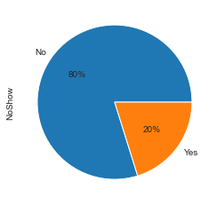

```python
# Plotting the ratio
df_noshow['NoShow'].value_counts().plot(kind='pie',autopct='%1.0f%%');
```

As we can see 20% of the patients did not show up for their appointments while the rest 80% did.

### Question 2: What was the distribution like for appointment waiting times?

After categorizing the waiting times into different timeframes like same day, short wait, 1 week, etc; here we will visualize the total count of appointments that fell into category and see how they all compare.

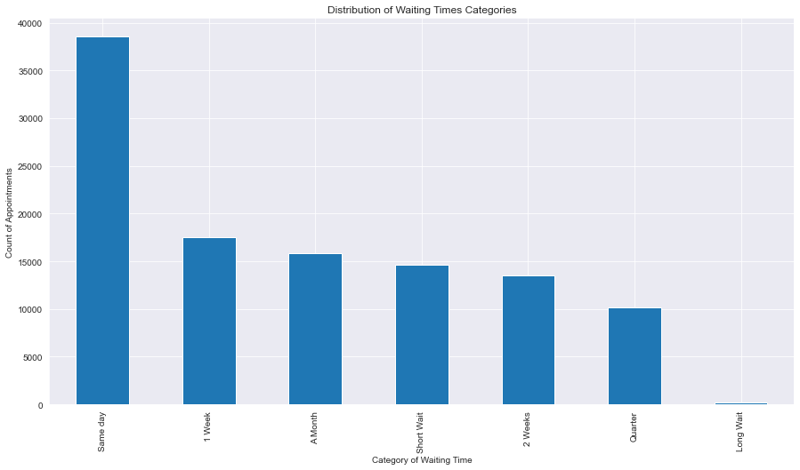

```python
# Plotting the distribution
df_noshow['CategoryWT'].value_counts().plot(kind='bar',figsize=(15,8));
plt.ylabel('Count of Appointments')
plt.xlabel('Category of Waiting Time')
plt.title('Distribution of Waiting Times Categories')
```

```python
# Calculate the % breakdown of the waiting time category by dividing the len of the appointments
catWT_per = df_noshow['CategoryWT'].value_counts()/len(df_noshow['AppointmentID'])*100
catWT_per
```

```
Same day      34.891107
1 Week        15.843143
A Month       14.357452
Short Wait    13.278020
2 Weeks       12.240208
Quarter        9.193728
Long Wait      0.196343
Name: CategoryWT, dtype: float64
```

From the bar chart we can see "Same day" appointments had the highest total count while "Long Wait" had the lowest total count of appointments. You can refer to the timeframe category breakdown here.

### Question 3: What areas had the shortest and longest wait times?

As the question clearly states, we are looking to find which areas had the longest waiting time and those that had the shortest waiting time too. Here, we will first find the max and min waiting times and then match these waiting times with areas that had these exact times.

```python
# Find the max waiting time value
lwt = df_noshow['WaitingTime'].max()
lwt
```

```
179
```

```python
# Find the min waiting time value
swt = df_noshow['WaitingTime'].min()
swt
```

```
0
```

```python
# Find areas with the max waiting times using panda query
a_lwt = df_noshow.query('WaitingTime == 179')
a_lwt.Neighbourhood.unique()
```

```
array(['MARUÍPE', 'SÃO CRISTÓVÃO'], dtype=object)
```

```python
# Find areas with the min waiting times using panda query
a_lwt = df_noshow.query('WaitingTime == 0')
a_lwt['Neighbourhood'].unique()
```

```
array(['JARDIM DA PENHA', 'MATA DA PRAIA', 'PONTAL DE CAMBURI',
       'ANDORINHAS', 'DA PENHA', 'TABUAZEIRO', 'BENTO FERREIRA',
       'SÃO PEDRO', 'SANTA MARTHA', 'SÃO CRISTÓVÃO', 'CONQUISTA',
       'NOVA PALESTINA', 'JARDIM CAMBURI', 'JABOUR', 'RESISTÊNCIA',
       'MONTE BELO', 'BONFIM', 'SANTO ANTÔNIO', 'BELA VISTA',
       'SANTA HELENA', 'MARIA ORTIZ', 'ITARARÉ', 'INHANGUETÁ',
       'UNIVERSITÁRIO', 'REDENÇÃO', 'SANTA CLARA', 'CENTRO',
       'PARQUE MOSCOSO', 'DO MOSCOSO', 'MARUÍPE', 'SANTOS DUMONT',
       'ARIOVALDO FAVALESSA', 'CARATOÍRA', 'ILHA DO FRADE', 'GURIGICA',
       'ILHA DE SANTA MARIA', 'JOANA D´ARC', 'PRAIA DO CANTO',
       'REPÚBLICA', 'SÃO BENEDITO', 'SANTO ANDRÉ', 'SANTA LÚCIA',
       'BARRO VERMELHO', 'SANTA LUÍZA', 'FONTE GRANDE', 'SÃO JOSÉ',
       'JESUS DE NAZARETH', 'ROMÃO', 'PIEDADE', 'ILHA DAS CAIEIRAS',
       'VILA RUBIM', 'FORTE SÃO JOÃO', 'GRANDE VITÓRIA', 'SANTA TEREZA',
       'DO CABRAL', 'MÁRIO CYPRESTE', 'ESTRELINHA', 'HORTO', 'DO QUADRO',
       'SOLON BORGES', 'SEGURANÇA DO LAR', 'CRUZAMENTO',
       'ANTÔNIO HONÓRIO', 'PRAIA DO SUÁ', 'CONSOLAÇÃO', 'FRADINHOS',
       'GOIABEIRAS', 'ILHA DO PRÍNCIPE', 'BOA VISTA', 'DE LOURDES',
       'JUCUTUQUARA', 'COMDUSA', 'SANTOS REIS', 'ENSEADA DO SUÁ',
       'ILHA DO BOI', 'SANTA CECÍLIA', 'NAZARETH', 'MORADA DE CAMBURI',
       'AEROPORTO', 'PARQUE INDUSTRIAL'], dtype=object)
```

```python
# Find the total count of areas that had the shortest waiting time
a_lwt['Neighbourhood'].nunique()
```

```
80
```

We can see the max waiting time is 179 days and the shortest was 0 days. MARUÍPE and SÃO CRISTÓVÃO had the longest waiting times of 179 days while 80 other areas the shortest waiting times of 0 days.

### Question 4: Timeframes with the most and least appointments?

Here we want to find the total count of appointments that fell in each waiting time category. After getting the total count, look which category had the most and least appointments.

```python
# Find time categories with most appointments
# Check value count of time categories
ma = df_noshow['CategoryWT'].value_counts()
ma
```

```
Same day      38562
1 Week        17510
A Month       15868
Short Wait    14675
2 Weeks       13528
Quarter       10161
Long Wait       217
Name: CategoryWT, dtype: int64
```

"Same day" appointments had the highest count at 38562 while "Long Wait" appointments had the lowest at 217.

### Question 5: Is there a correlation between the waiting time and no-show ups?

In this question, we are looking at whether there is a correlation between the length of the waiting time and the rate of showing up or not showing up for appointments.

```python
# Copying wt_ns
cpwt_ns = wt_ns.copy()

# Making the index as a column in order to be plotted
cpwt_ns.reset_index(drop=False, inplace=True)

# Transforming the NoShow Rate into strings with the % values
cpwt_ns['NoShow %'] = cpwt_ns['NoShow Rate'].apply(lambda x: '{0:.2f}%'.format(x))

# Multiplying the rate values by 500 times for easier plotting
cpwt_ns['NoShowing Rate'] = cpwt_ns['NoShow Rate']*500

cpwt_ns
```

| NoShow | CategoryWT | No | Yes | NoShow Rate | NoShow % | NoShowing Rate |
| --- | --- | --- | --- | --- | --- | --- |
| 0 | 1 Week | 13097 | 4413 | 33.694739 | 33.69% | 16847.369627 |
| 1 | 2 Weeks | 9362 | 4166 | 44.499039 | 44.50% | 22249.519333 |
| 2 | A Month | 10709 | 5159 | 48.174433 | 48.17% | 24087.216360 |
| 3 | Long Wait | 161 | 56 | 34.782609 | 34.78% | 17391.304348 |
| 4 | Quarter | 6792 | 3369 | 49.602473 | 49.60% | 24801.236749 |
| 5 | Same day | 36770 | 1792 | 4.873538 | 4.87% | 2436.769105 |
| 6 | Short Wait | 11316 | 3359 | 29.683634 | 29.68% | 14841.816896 |

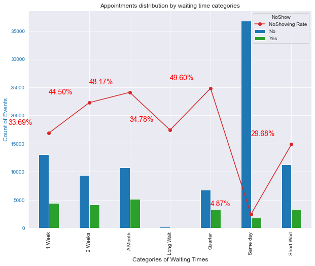

```python
# Define graph size
fig1, ax = plt.subplots(figsize=[10,10])
fig1.subplots_adjust(top=0.72)
plt.title('Appointments distribution by waiting time categories')

# Graph colors
colors = ['tab:blue', 'tab:green', 'tab:red']

# Set the y-axis color and label
ax.set_ylabel('Count of Events', color=colors[0], fontsize=12)
ax.tick_params(axis='y', labelcolor=colors[0])

# Plotting the line chart:
cpwt_ns[['CategoryWT', 'NoShowing Rate']].plot(x='CategoryWT', linestyle='-', marker='o', ax=ax, color=colors[2])

#Setting the line chart marker labels by getting the x-axis ticks to plot the label
x = ax.get_xticks()
for a,b,c in zip(x,cpwt_ns['NoShowing Rate'], cpwt_ns['NoShow %']):
    plt.text(a,b+1500,c, color='red', fontsize=14)

# Plotting the bar chart:
cpwt_ns[['CategoryWT', 'No', 'Yes']].plot(x='CategoryWT', kind='bar', ax=ax, color=colors[0:2],)

#Set the y-axis color and label
ax.set_xlabel('Categories of Waiting Times', fontsize=12)

plt.show()
```

We can see as the length of the waiting time increases so does the rate of patients missing their appointments increase. However, the rate of missing appointments for the "Long Wait" drops opposite to the patterns of the other timeframes. This needs further investigation.

### Question 6: What gender was most likely to miss their appointments?

Looking at the appointments, the goal here is to break them down by gender and find which gender was most likely to miss their appointment by getting the total count of missed appointments by each gender.

```python
# Grouping the df by Gender and NoShow status
g_ns = df_noshow.groupby(["Gender","NoShow"]).count()
g_ns
```

| Gender | NoShow | PatientId | AppointmentID | ScheduledDay | AppointmentDay | Age | Neighbourhood | Scholarship | Hypertension | Diabetes | Alcoholism | Handicap | SmsReceived | WaitingTime | CategoryWT |
| --- | --- | --- | --- | --- | --- | --- | --- | --- | --- | --- | --- | --- | --- | --- | --- |
| F | No | 57245 | 57245 | 57245 | 57245 | 57245 | 57245 | 57245 | 57245 | 57245 | 57245 | 57245 | 57245 | 57245 | 57245 |
|  | Yes | 14591 | 14591 | 14591 | 14591 | 14591 | 14591 | 14591 | 14591 | 14591 | 14591 | 14591 | 14591 | 14591 | 14591 |
| M | No | 30962 | 30962 | 30962 | 30962 | 30962 | 30962 | 30962 | 30962 | 30962 | 30962 | 30962 | 30962 | 30962 | 30962 |
|  | Yes | 7723 | 7723 | 7723 | 7723 | 7723 | 7723 | 7723 | 7723 | 7723 | 7723 | 7723 | 7723 | 7723 | 7723 |

[figure not shown]

```python
# Ploting for the above grouped df: Gender & NoShow
g_ns["PatientId"].unstack().plot(kind="bar",stacked=False,figsize=(10,6),grid=True)
plt.title("Gender and NoShow")
plt.legend(["Didn't Show Up", "Showed Up"])
plt.ylabel("Patient Count");
```

Looking at the numbers we can see we had more female patients compared to their male counterparts who had appointments. Breaking down further, we can also see more female patients missed their appointments compared to male patients. Further investigation is needed into this as we can't tell by this, whether it is because there are more female patients or there are more reasons behind this.

### Question 7: Which area was hit headest by patients who didn't show up?

Here we are trying to figure out which areas had the highest cases of patients not showing up for their appointments.

```python
# Group and then find count of NoShow by Neighbourhood
a_ns = df_noshow.groupby(['Neighbourhood','NoShow']).count()
a_ns
```

| Neighbourhood | NoShow | PatientId | AppointmentID | Gender | ScheduledDay | AppointmentDay | Age | Scholarship | Hypertension | Diabetes | Alcoholism | Handicap | SmsReceived | WaitingTime | CategoryWT |
| --- | --- | --- | --- | --- | --- | --- | --- | --- | --- | --- | --- | --- | --- | --- | --- |
| AEROPORTO | No | 7 | 7 | 7 | 7 | 7 | 7 | 7 | 7 | 7 | 7 | 7 | 7 | 7 | 7 |
|  | Yes | 1 | 1 | 1 | 1 | 1 | 1 | 1 | 1 | 1 | 1 | 1 | 1 | 1 | 1 |
| ANDORINHAS | No | 1741 | 1741 | 1741 | 1741 | 1741 | 1741 | 1741 | 1741 | 1741 | 1741 | 1741 | 1741 | 1741 | 1741 |
|  | Yes | 521 | 521 | 521 | 521 | 521 | 521 | 521 | 521 | 521 | 521 | 521 | 521 | 521 | 521 |
| ANTÔNIO HONÓRIO | No | 221 | 221 | 221 | 221 | 221 | 221 | 221 | 221 | 221 | 221 | 221 | 221 | 221 | 221 |
| ... | ... | ... | ... | ... | ... | ... | ... | ... | ... | ... | ... | ... | ... | ... | ... |
| TABUAZEIRO | Yes | 572 | 572 | 572 | 572 | 572 | 572 | 572 | 572 | 572 | 572 | 572 | 572 | 572 | 572 |
| UNIVERSITÁRIO | No | 120 | 120 | 120 | 120 | 120 | 120 | 120 | 120 | 120 | 120 | 120 | 120 | 120 | 120 |
|  | Yes | 32 | 32 | 32 | 32 | 32 | 32 | 32 | 32 | 32 | 32 | 32 | 32 | 32 | 32 |
| VILA RUBIM | No | 710 | 710 | 710 | 710 | 710 | 710 | 710 | 710 | 710 | 710 | 710 | 710 | 710 | 710 |
|  | Yes | 141 | 141 | 141 | 141 | 141 | 141 | 141 | 141 | 141 | 141 | 141 | 141 | 141 | 141 |

160 rows × 14 columns

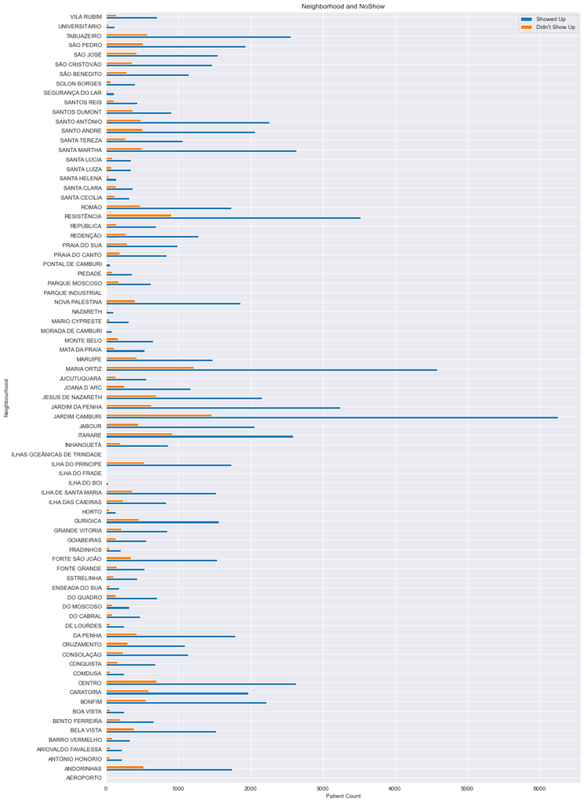

```python
# Ploting for the above grouped df: Gender & NoShow
a_ns["PatientId"].unstack().plot(kind="barh",figsize=(15,25))
plt.title("Neighborhood and NoShow")
plt.legend(["Showed Up","Didn't Show Up"])
plt.xlabel("Neighborhood")
plt.xlabel("Patient Count");
```

Jardim Camburi had the highest number of patients missing their appoinments but also had the highest number of patient appointments.

### Question 8: Which areas had the most and least appointments?

Looking at the number of appointments, we are trying to figure out which areas had the most and least number of patient appointments.

```python
# Check count of appointments by Neighbourhood
Neigh_appoint = df_noshow['Neighbourhood'].value_counts()
Neigh_appoint
```

```
JARDIM CAMBURI                 7717
MARIA ORTIZ                    5805
RESISTÊNCIA                    4430
JARDIM DA PENHA                3877
ITARARÉ                        3514
                               ...
ILHA DO BOI                      35
ILHA DO FRADE                    10
AEROPORTO                         8
ILHAS OCEÂNICAS DE TRINDADE       2
PARQUE INDUSTRIAL                 1
Name: Neighbourhood, Length: 81, dtype: int64
```

```python
# Check max value
Neigh_appoint.max()
```

```
7717
```

```python
# Check min value
Neigh_appoint.min()
```

```
1
```

JARDIM CAMBURI had the most patient appointments with 7717 appointments and PARQUE INDUSTRIAL had the least with 1 appointment.

In this case, we are trying to figure out whether sending a reminder sms to patients who had appointments had an influence on whether the patient showed up for their appointment or not.

```python
# Count patients who turned up and received an sms
sms_ns1 = df_noshow[df_noshow["SmsReceived"] == 1]["NoShow"].count()
sms_ns1
```

```
35482
```

```python
# Count patients who did show up but didn't received an sms
sms_ns0 = df_noshow[df_noshow["SmsReceived"] == 0]["NoShow"].count()
sms_ns0
```

```
75039
```

### Question 10: What factors correlate?

Here we want to take a look at the dataset's features and how they relate, to what degree and in which direction they do.

```python
df_noshow.corr().style.background_gradient(cmap='Blues')
```

|  | Age | Scholarship | Hypertension | Diabetes | Alcoholism | Handicap | SmsReceived | WaitingTime |
| --- | --- | --- | --- | --- | --- | --- | --- | --- |
| Age | 1.000000 | -0.092469 | 0.504599 | 0.292398 | 0.095811 | 0.083827 | 0.012629 | 0.034813 |
| Scholarship | -0.092469 | 1.000000 | -0.019738 | -0.024899 | 0.035019 | -0.009068 | 0.001182 | -0.030435 |
| Hypertension | 0.504599 | -0.019738 | 1.000000 | 0.433082 | 0.087967 | 0.084949 | -0.006285 | -0.017236 |
| Diabetes | 0.292398 | -0.024899 | 0.433082 | 1.000000 | 0.018471 | 0.059204 | -0.014561 | -0.027200 |
| Alcoholism | 0.095811 | 0.035019 | 0.087967 | 0.018471 | 1.000000 | 0.003715 | -0.026154 | -0.038527 |
| Handicap | 0.083827 | -0.009068 | 0.084949 | 0.059204 | 0.003715 | 1.000000 | -0.025148 | -0.020885 |
| SmsReceived | 0.012629 | 0.001182 | -0.006285 | -0.014561 | -0.026154 | -0.025148 | 1.000000 | 0.398128 |
| WaitingTime | 0.034813 | -0.030435 | -0.017236 | -0.027200 | -0.038527 | -0.020885 | 0.398128 | 1.000000 |

Looking at the correlation heatmap, the darker the color the greater the correlation. Features that greatly correlate include Hypertension and Age, Hypertension and Diabetes, SmsReceived and WaitingTime, and Diabetes and Age.

## Conclusions

> About 20% of the appointments made ended with the patients not turning up.

> MARUÍPE and SÃO CRISTÓVÃO had the longest waiting time.

> As the waiting time increased so did the number of patients who didn't show up increase. However, the longest waiting time(between 90 and 180 days) did have an decrease in patients who didn't show up and this needs further investigation as to why this is the case.

> The highest correlation was concetrated around hypertension and age, diabetes and hypertension, waiting time and sms received, diabetes and age.

> The neighborhood of Jardim Camburi recorded the highest missed appointments, the highest compared to the other neighborhoods.

## Limitations

From the dataset provided, there are two columns that did seem swapped based on the dataset description. I am tempted to believe that the Handicap and SmsReceived values have been swapped based on boolean datatype in the description. However, due to the limited time I have to work on this I will not be investigating this further.

To make more meaning of the dataset, I think the dataset needed more features to further explain why the patients behaved the way they did.

Due to my limited expertise and time, I was not able to do some preditions using machine learning. I had some ideas on just using machine learning to do the analysis for me by predicting show-up rates and factors that carried heavy influence in predicting this.

### References

[UsageError: Line magic function `%` not found. Jupyter Notebook](https://stackoverflow.com/questions/52874240/usageerror-line-magic-function-not-found-jupyter-notebook)

[Pandas – Delete rows based on column values](https://datascienceparichay.com/article/pandas-delete-rows-based-on-column-values/)

How to Solve Python TypeError: ‘method’ object is not subscriptable

[Is the Handcap and SMS_received columns swapped?](https://www.kaggle.com/datasets/joniarroba/noshowappointments/discussion/202717)

[Finding top 10 in a dataframe in Pandas](https://stackoverflow.com/questions/43859416/finding-top-10-in-a-dataframe-in-pandas)

[How to Create a Seaborn Correlation Heatmap in Python?](https://medium.com/@szabo.bibor/how-to-create-a-seaborn-correlation-heatmap-in-python-834c0686b88e)

```python
from subprocess import call
call(['python', '-m', 'nbconvert', 'Investigate_a_Dataset.ipynb'])
```

[output not shown]

[output cut: 124 more lines]

[output not shown]

[output not shown]

```
255
```